# Inference for a Mean - Sigma Unknown

Hypothesis Testing and Confidence Intervals

Author

Nathan Lunceford

# Review

When we know what the population standard deviation, $\sigma$, for individuals, we can calculate Z-scores and use the Standard Normal Distribution to calculate probabilities. We can think of Z as having a standard normal distribution, meaning it has a mean of 0 and a standard deviation of 1.

$$z= \frac{\bar{x} - \mu}{\frac{\sigma}{\sqrt{n}}}$$

Though rare, there are situations where we might know the population standard deviation from published research or census data. Standardized tests, for example, publish population-level summaries which would allow us to test how our sample compares to the general population using the Z formula.

## Hypothesis Testing

When testing a null hypothesis, the $\mu$ in the z-score formula becomes the hypothesized population mean. Our z-score is then interpreted as the number of standard deviations away from the *hypothesized* mean. If we know the population standard deviation, $\sigma$, then we can calculate the probability of getting a sample mean more extreme than the one we observed if the null hypothesis is true.

**KEY DEFINITION**: A **P-value** is the probability of observing a test statistic as extreme, or more extreme than the one we observed in our sample, *if the null hypothesis is true*.

**EXAMPLE**: A factory claims its light bulbs last, on average, $\mu = 800$ hours with a standard deviation, $\sigma = 40$. We randomly select 40 light bulbs to test to see if the life expectancy is actually less than that.

State the Null and alternative Hypotheses:

$$H_0: \mu = 800$$

$$H_a: \mu < 800$$

Calculate the Z-score and find the P-value for the test:  
**p-value= .00885, z-score=-2.371708 if x bar is 785.**

State your conclusion:  
**If xbar of a sample size of 40 is 785 then the p-score would be low enought to reject the null hypothesis.**

## Confidence Interval

We can also calculate a confidence interval for the above example. Recall the formula for a confidence interval is, for a given z* associated with a desired level of confidence:

$$CI = \bar{x} \pm z^*\frac{\sigma}{\sqrt{n}}$$

Recall the z* for common confidence levels:

```r
library(tidyverse)
library(pander)
tibble(`Conf. Level` = c(0.99, 0.95, 0.90), `Z*` = c(2.576, 1.96, 1.645)) %>% pander()
```

| Conf. Level | Z* |
| --- | --- |
| 0.99 | 2.576 |
| 0.95 | 1.96 |
| 0.9 | 1.645 |

# Student’s T-Distribution (sigma unkown)

In most cases, we are performing statistical analyses on data collected and do not know the population standard deviation $\sigma$. In this situation, we can no longer use the Standard Normal Distribution. We use a distribution that is similar to the Normal distribution but whose shape depends on how much data we have. The Student’s t-distribution requires a t-value (like a z-score) and something called degrees of freedom. Degrees of Freedom for a t-distribution are defined:

$$df = n-1$$

We calculate test statistics very similarly, but we replace the population standard deviation with the sample standard deviation.

$$t = \frac{\bar{x} - \mu}{\frac{s}{\sqrt{n}}}$$

The T-distribution is very similar to the standard normal. It is symmetrical around zero. However, the shape depends on how much data you have. The more data you have, the closer the $t$ is to the standard normal. This is illustrated in the graph below:

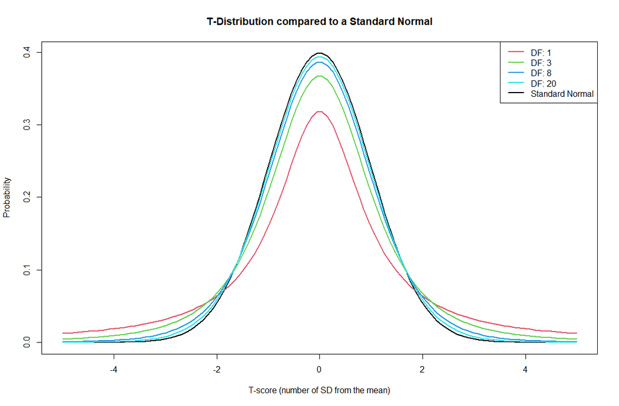

Because $t$ is not normally distributed, we can’t use pnorm(). However, R is fully capable of calculating probabilities for many different probability distributions including the t-distribution. We just have to give it a t-value and the degrees of freedom.

## Calculating P-values by hand with the T Distribution (NOT RECOMMENDED)

Suppose we have 25 test scores defined as “data” in the code chunk below. We can calculate the t-statistic just like we did with the z-score.

Suppose we believe that the mean score of these 25 students is significantly higher than 50. Our null and alternative hypothesis are as follows:

$$H_0: \mu = 50$$
$$H_a: \mu > 50$$

```r
# we can use the t-distribution, pt(), just like pnorm() but must also add the degrees of freedom

data <- c(88,81,27,92,46,79,67,44,46,88,21,60,71,81,79,52,100,44,42,58,52,48,83,65,98)

# Hypothesized Mean:
mu_0 <- 50

# Sample size, sample Mean and sample SD
#  The length function tells us how many data points are in the list.
n <- length(data)
xbar <- mean(data)
s <- sd(data)

s_xbar = s / sqrt(n)

t <- (xbar - mu_0) / s_xbar

# Probability of getting a test statistic at least as extreme as the one we observed if the null hypothesis is true
1-pt(t, n-1)
```

```
[1] 0.00151866
```

This means that if the true population mean was 50, then there is only a 0.00152 probability of observing a test statistic, t, as high as the one we got (**P-value**).

The good news is that the more complicated the math becomes, the less of it we have to do! Instead of using R like a calculator to calculate z or t scores and calculating probabilities “by hand” (using `pnorm()` or `pt()`), we can use R functions on the data directly and get much more useful output.

# The New Hotness

For situations where we want to make inference about a population from our sample data, we will be following these basic steps:

1. Read in the data
2. Review the data
3. Visualize the data
4. Perform the appropriate analysis

This will be true regardless of the type of data and analysis. Let’s begin by looking at a familiar dataset. In the following example, we will focus on the Extroversion scores from Brother Cannon’s Math 221 classes.

## Step 1: Read in the data

```r
# Load Libraries

library(tidyverse)
library(mosaic)
library(rio)
library(car)


# Read in data
big5 <- import('https://raw.githubusercontent.com/byuistats/Math221D_Cannon/master/Data/All_class_combined_personality_data.csv')
```

## Step 2: Review the Data

In this step, we are looking to see if the data are as expected. Are the columns we’re interested in numeric? Categorical? and do these match expectations. We can also start to look for strange data and outliers. Visualizations can assist with that as well. Other common issues to look for include: negative numbers that should only be positive, date values that shouldn’t exist, missing values, character variables inside what should be a number.

In the real world, data are messy. Reviewing the data is a critical part of an analysis.

Take a look through the personality dataset and see if there are any anomalies that might need to be addressed.  
**Missing value in Extroversion column**

```r
#View(big5)
#glimpse(big5)
#head(big5)

fav <- favstats(big5$Extroversion)
fav
```

```
 min Q1 median Q3 max     mean       sd   n missing
   1 42     58 73 100 56.98267 21.09599 404       1
```

## Step 3: Visulize the data

So far we have been discussing a single, quantitative variable of interest, like test scores, reaction times, heights, etc. When we start looking at more complicated data, we will expand our repertoire of visualizations, but Histograms are very good when looking at one variable at a time, and boxplots are very good for comparison between groups.

Create a histogram of Extroversion. Describe some features of the data. Is it symmetric? Skewed? Are there outliers?

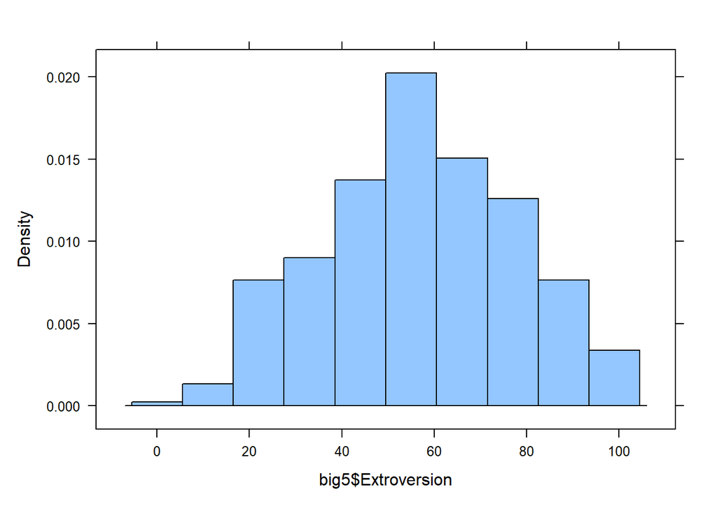

```r
# Basic Graph
histogram(big5$Extroversion)
```

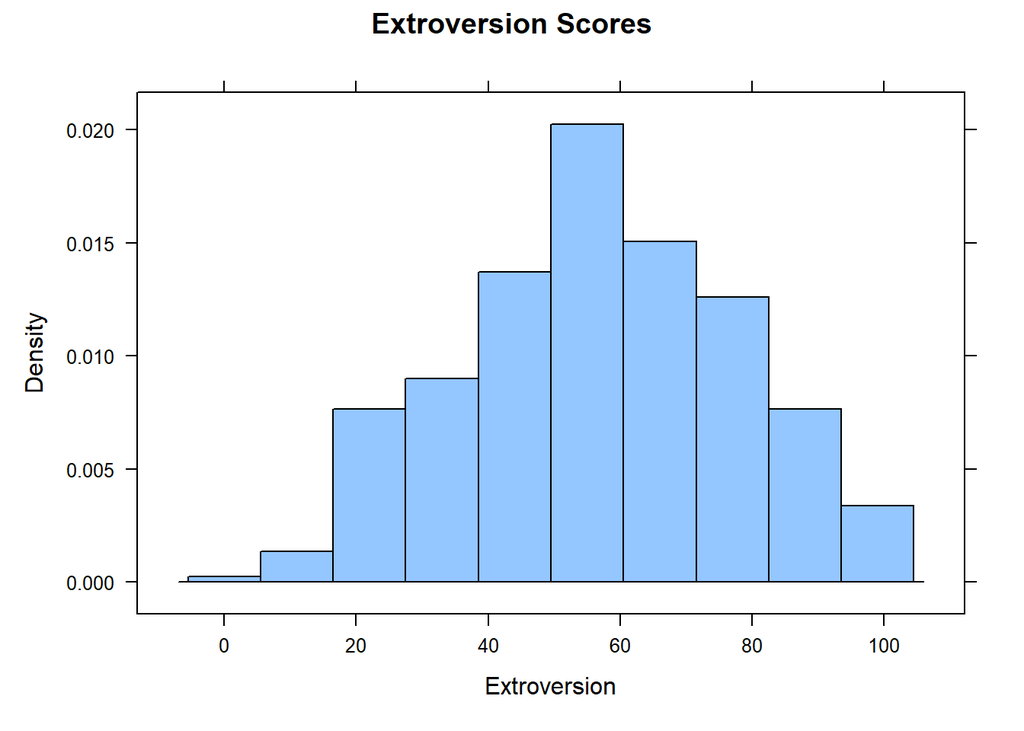

```r
# Improved graph
histogram(big5$Extroversion, main = "Extroversion Scores", xlab = "Extroversion")
```

**It looks to be slightly left skewed.**

## Step 4: Perform the appropriate analysis

In this example, we will be testing the hypothesis that Brother Cannon’s students are similar to the general population. We suspect that these youthful BYU-I students are, on average, more extroverted.

### Hypothesis Test

Write out the Null and alternative hypotheses.

$$H_0: \mu_{extroversion} = 50$$

$$H_A: \mu_{extroversion} > 50$$

$$\alpha = 0.05$$

Perform the one-sample t-test using the “t.test()” function in R. If you ever get stuck remembering how to use a function in R, you can run `?t.test` to see documentation. The question mark will open up the help files for any given function in R.

```r
#?t.test

# One-sided Hypothesis Test
t.test(big5$Extroversion, mu = 50, alternative = "greater")
```

```
    One Sample t-test

data:  big5$Extroversion
t = 6.6529, df = 403, p-value = 4.697e-11
alternative hypothesis: true mean is greater than 50
95 percent confidence interval:
 55.25232      Inf
sample estimates:
mean of x
 56.98267
```

**Q**: What is the P-value?  
**4.697e-11**

**Q**: How do we explain our conclusion in context of our research question?

**Technical Conclusion**: We reject the null hypothesis.

**Contextual Conslusion**:

### Confidence Intervals

We can also use the `t.test()` function to create confidence intervals. Recall that **confidence intervals are always 2-tailed**. Confidence intervals are typically written in the form: (lower limit, upper limit).

```r
# Confidence Intervals are by definition 2-tailed
# We can also change the confidence level

t.test(big5$Extroversion, mu = 50, alternative = "two.sided", conf.level = .99)
```

```
    One Sample t-test

data:  big5$Extroversion
t = 6.6529, df = 403, p-value = 9.394e-11
alternative hypothesis: true mean is not equal to 50
99 percent confidence interval:
 54.26631 59.69903
sample estimates:
mean of x
 56.98267
```

```r
# If we only want the output to show the confidence interval and not the hypothesis test, we can use a `$` to select specific output:
# Because the default option for the `alternative =`  in the t.test fucntion is "two.sided", we don't actually need to include it

t.test(big5$Extroversion, mu = 50, conf.level = .99)$conf.int
```

```
[1] 54.26631 59.69903
attr(,"conf.level")
[1] 0.99
```

Describe in words the interpretation of the confidence interval in context of Extroversion.  
**The 99% confidence interval for the mean Extroversion score of Brother Cannon’s students ranges from 54.27 to 59.70. This means that we are 99% confident that the true mean Extroversion score of all Brother Cannon’s students falls within this interval.**

# Your Turn

## Body Temperature Data

The data below contains information about body temperatures of healthy adults.

### Load the data:

```r
# These lines load the data into the data frame body_temp:

body_temp <- import("https://byuistats.github.io/M221R/Data/body_temp.xlsx")
```

### Review the Data

What is the mean and standard deviation of the body temperatures in our data set?

**mean=98.23, sd=.74**

```r
glimpse(body_temp)
```

```
Rows: 148
Columns: 3
$ gender      <chr> "Male", "Female", "Female", "Male", "Female", "Male", "Mal…
$ temperature <dbl> 98.0, 99.6, 97.8, 97.6, 98.7, 98.4, 98.9, 97.1, 99.2, 97.4…
$ source      <chr> "Representative data from:", "Mackowiak, P. A., Wasserman,…
```

```r
mean_temp <- mean(body_temp$temperature)
sd_temp <- sd(body_temp$temperature)

mean_temp
```

```
[1] 98.23446
```

```r
sd_temp
```

```
[1] 0.7375924
```

### Visualize the Data

Create a histogram to visualize the body temperature data. Which of the following best describes the distribution of the data?  
**It is approximately normal, maybe right skewed.**

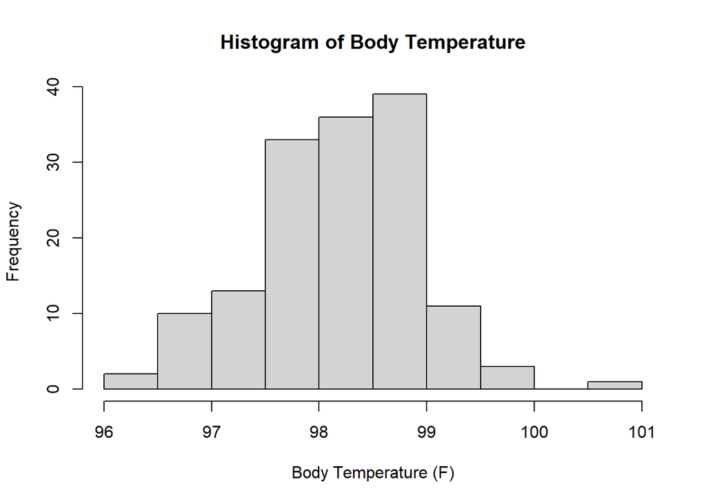

```r
hist(body_temp$temperature, main = "Histogram of Body Temperature", xlab = "Body Temperature (F)", breaks = 10)
```

### Analyze the Data

It’s widely accepted that normal body temperature for healthy adults is 98.6 degrees Fahrenheit.

Suppose we suspect that the average temperature is different than 98.6

Use a significance level of $\alpha = 0.01$ to test whether the mean body temperature of healthy adults is equal to 98.6 degrees Fahrenheit.

What is the P-value?  
**1.272e-08**

Explain our conclusion.  
**We reject the null hypothesis because the p-value is less than the significance level.**

```r
t_test_result <- t.test(body_temp$temperature, mu = 98.6, alternative = "two.sided", conf.level = 0.99)

p_value <- t_test_result$p.value

t_test_result
```

```
    One Sample t-test

data:  body_temp$temperature
t = -6.0291, df = 147, p-value = 1.272e-08
alternative hypothesis: true mean is not equal to 98.6
99 percent confidence interval:
 98.07623 98.39268
sample estimates:
mean of x
 98.23446
```

```r
p_value
```

```
[1] 1.272295e-08
```

Create a 99% confidence interval for the true population average temperature of healthy adults.

```r
conf_interval <- t_test_result$conf.int

conf_interval
```

```
[1] 98.07623 98.39268
attr(,"conf.level")
[1] 0.99
```